# IODS course project

Laura Pietikäinen

# Introduction to Open Data Science - Course Project

# About the project

```r
# This is a so-called "R chunk" where you can write R code.

date()
```

```
## [1] "Mon Nov 28 18:22:18 2022"
```

## Thoughts about the course

I have been wanting to learn **R markdown** for a while but have lacked *time* and a *good way* to start learning. Now that I have chance to learn it as well as get better with R, I am very excited. I have used R for a while now, but my skills have relied on active googling. There is nothing wrong with active googling, but it felt nice to understand the background a little bit better and I am sure my data analysis will get better too. I learned some new functions such as spec and near during the first set of exercises.

[Here is a link to my GitHub repository](https://github.com/laurapie/IODS-project)

# Regression and model validation

This week I have worked on linear regression and learned more about how the markdown works. I had not realised that I do not need to start every note or text I write with a #, since I will write the code in chunks which leaves the rest of the script for notes. It felt rewarding to write this code and see the results in the html file. Otherwise I some technical issues colored this week. Firstly, I had some issues with pushing the changes to GitHub which I managed to fix by always starting the new script with adding the personal access token. Secondly, the keyboard of my laptop broke partly resulting to a malfunction of the buttons in the middle of the keyboard. The problem still remains but luckily I managed to dumpster-dive myself a functioning keyboard.

```r
date()
```

```
## [1] "Mon Nov 28 18:22:18 2022"
```

## Reading the file to R

```r
list.files()
```

```
##  [1] "chapter1.html"
##  [2] "chapter1.Rmd"
##  [3] "chapter2.html"
##  [4] "chapter2.Rmd"
##  [5] "chapter3.html"
##  [6] "chapter3.Rmd"
##  [7] "chapter4.html"
##  [8] "chapter4.Rmd"
##  [9] "Code_for_fixing_the_connection_to_github.R"
## [10] "create_alc.R"
## [11] "create_learning.R"
## [12] "data"
## [13] "data2.csv"
## [14] "Exercise1.Rmd"
## [15] "Exercise2.Rmd"
## [16] "Exercise3.Rmd"
## [17] "Exercise4.Rmd"
## [18] "index.html"
## [19] "index.Rmd"
## [20] "IODS-project.Rproj"
## [21] "README.md"
```

```r
student2014 <- read.csv("data2.csv", header = TRUE, sep = ",")
dim(student2014)
```

```
## [1] 166   7
```

```r
str(student2014)
```

```
## 'data.frame':    166 obs. of  7 variables:
##  $ gender  : chr  "F" "M" "F" "M" ...
##  $ age     : int  53 55 49 53 49 38 50 37 37 42 ...
##  $ attitude: num  3.7 3.1 2.5 3.5 3.7 3.8 3.5 2.9 3.8 2.1 ...
##  $ deep    : num  3.58 2.92 3.5 3.5 3.67 ...
##  $ stra    : num  3.38 2.75 3.62 3.12 3.62 ...
##  $ surf    : num  2.58 3.17 2.25 2.25 2.83 ...
##  $ points  : int  25 12 24 10 22 21 21 31 24 26 ...
```

## Contents of the data

Data is from an international survey of approaches to learning, made possible by teachers. The data is used as a course material in a course called Introduction to Open Data Science and it consists of seven variables and 166 observations.

### Variable contets briefly:

- gender = gender of the respondent (categorical)
- age = age of the respondent (integer)
- attitude = Global attitude toward statistics/10 (numerical)
- deep = mean of the values related to deep learning methods (numerical)
- stra = mean of the values related to strategic learning methods (numerical)
- surf = mean of the values related to surface learning methods (numerical)
- points = exam points (integer)

## Graphic overview of the data

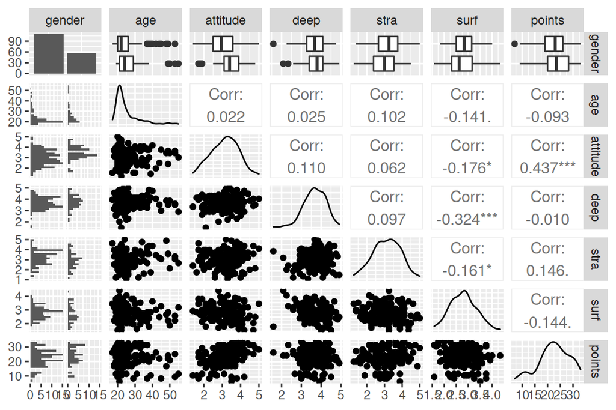

```r
library("ggplot2")
library("GGally")
ggpairs(student2014, lower = list(combo = wrap("facethist", bins = 20)))
```

### Significant correlations from the overview:

- attitude and points (R = 0.437***)
- deep and surf (R = -0.324***)
- stra and surf (R = -0.161*)

### Further focus on pairs with significant correlations and regression lines.

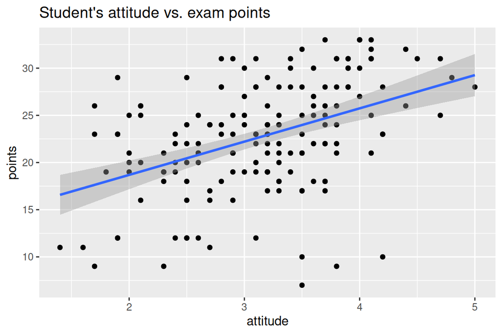

```r
#Access the gglot2 library
library(ggplot2)

# initialize plot with data and aesthetic mapping
p1 <- ggplot(student2014, aes(x = attitude, y = points))+
  geom_point()+
  geom_smooth(method = "lm")+
  ggtitle("Student's attitude vs. exam points")

p1
```

Students that had higher attitude scores obtained also higher exam points.

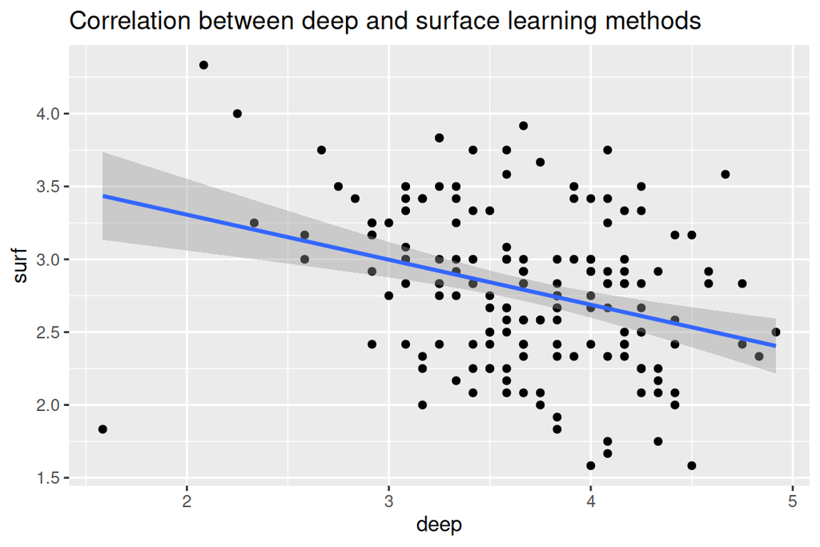

```r
p2 <- ggplot(student2014, aes(x = deep, y = surf))+
  geom_point()+
  geom_smooth(method = "lm")+
  ggtitle("Correlation between deep and surface learning methods")

p2
```

Students that used more surface learning techniques used less likely deep learning techniques.

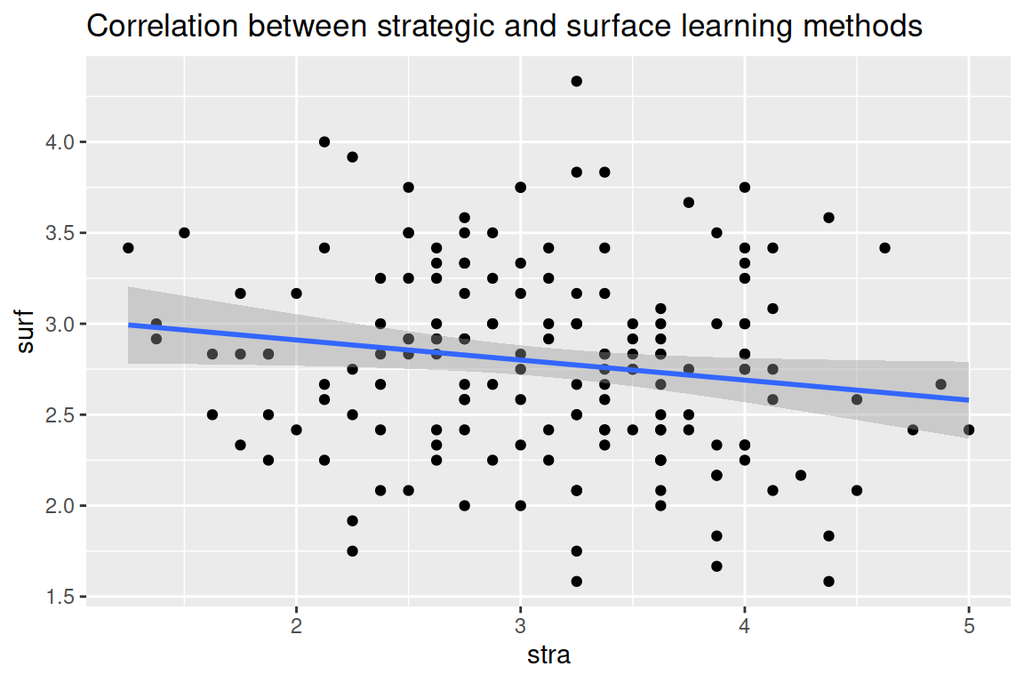

```r
p3 <- ggplot(student2014, aes(x = stra, y = surf))+
  geom_point()+
  geom_smooth(method = "lm")+
  ggtitle("Correlation between strategic and surface learning methods")

p3
```

Students that used surface techniques used strategic techniques less likely.

## Testing the model

```r
my_model <- lm(points ~ attitude + stra + surf + deep, data = student2014)
summary(my_model)
```

```
##
## Call:
## lm(formula = points ~ attitude + stra + surf + deep, data = student2014)
##
## Residuals:
##      Min       1Q   Median       3Q      Max
## -16.7335  -3.1992   0.7975   3.4002  11.6582
##
## Coefficients:
##             Estimate Std. Error t value Pr(>|t|)
## (Intercept)  15.4000     5.0245   3.065  0.00255 **
## attitude      3.4362     0.5739   5.987 1.34e-08 ***
## stra          0.8847     0.5411   1.635  0.10398
## surf         -0.9105     0.8390  -1.085  0.27948
## deep         -1.0072     0.7870  -1.280  0.20247
## ---
## Signif. codes:  0 '***' 0.001 '**' 0.01 '*' 0.05 '.' 0.1 ' ' 1
##
## Residual standard error: 5.286 on 161 degrees of freedom
## Multiple R-squared:  0.2154, Adjusted R-squared:  0.1959
## F-statistic: 11.05 on 4 and 161 DF,  p-value: 6.057e-08
```

Only attitude seems to correlate with the exam points (p = 1.34e-08, p<0.001). To make a model that fits better, I will remove the non-significant variables from the model.

## Removing the excess variables from the model

```r
my_model2 <- lm(points ~ attitude, data = student2014)
summary(my_model2)
```

```
##
## Call:
## lm(formula = points ~ attitude, data = student2014)
##
## Residuals:
##      Min       1Q   Median       3Q      Max
## -16.9763  -3.2119   0.4339   4.1534  10.6645
##
## Coefficients:
##             Estimate Std. Error t value Pr(>|t|)
## (Intercept)  11.6372     1.8303   6.358 1.95e-09 ***
## attitude      3.5255     0.5674   6.214 4.12e-09 ***
## ---
## Signif. codes:  0 '***' 0.001 '**' 0.01 '*' 0.05 '.' 0.1 ' ' 1
##
## Residual standard error: 5.32 on 164 degrees of freedom
## Multiple R-squared:  0.1906, Adjusted R-squared:  0.1856
## F-statistic: 38.61 on 1 and 164 DF,  p-value: 4.119e-09
```

## Assumptions of the model based on diagnostic plots

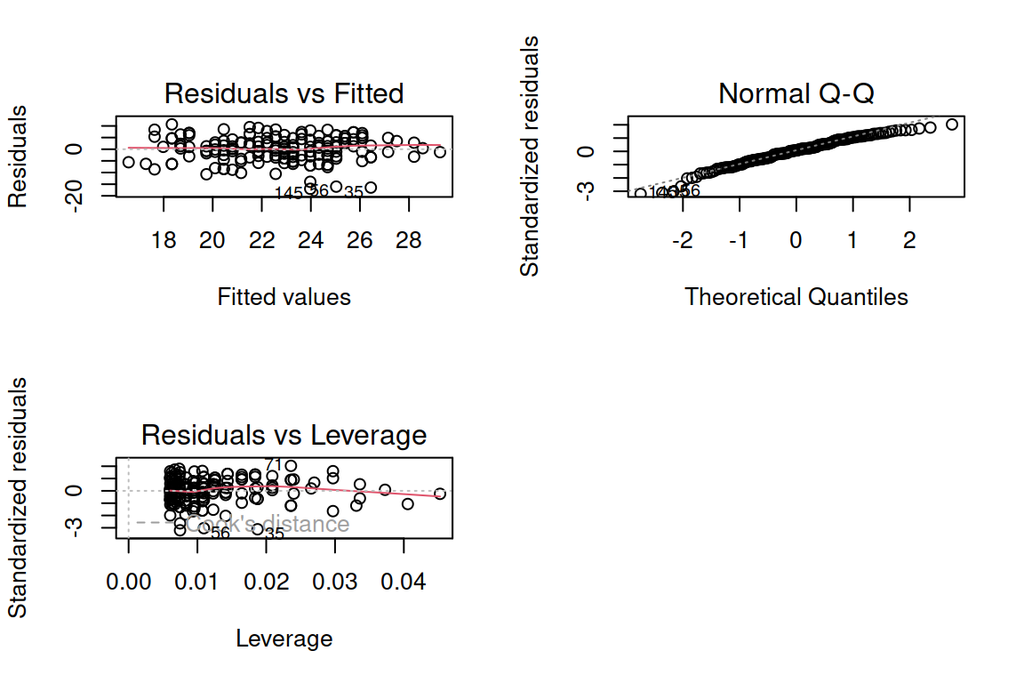

```r
par(mfrow=c(2,2))
plot(my_model2, which = c(1, 2, 5))
```

Residuals vs. leverage provides information on whether there are influential data points that might disturb the model by being for example mistakes in the data. Residuals might be skewed since there is a change in the spread of the values with smaller leverage having higher spread than the ones with higher leverage. When looking at all of the plots, it seems like entries 145, 56 and 35 might be outliers, that should be checked in case of a mistake in the data. Otherwise qq-plot distribution is relatively close to the line. Also the residuals vs. fitted plot looks otherwise good.

# Logistic regression

## Diary

This week I learned more about logistic regression. This is probably one of the most useful parts of the course for me since I am going to use these methods on my seed bank germination data. Thus, I will likely return to these exercises and methods many times in the near future since this time I couldn’t use as much time on these exercises as I would have wanted. This week I did not have any problems with committing or pushing, yay!

## Reading the data and exploring the structure

```r
getwd()
```

```
## [1] "/home/local/pielaura/Documents/zasemaemulaattori/Documents/kurssit/Introduction_to_open_data_science/excerices_1/IODS-project"
```

```r
setwd("/home/local/pielaura/Documents/zasemaemulaattori/Documents/kurssit/Introduction_to_open_data_science/excerices_1/IODS-project/data")
studentalc <- read.csv("alc.csv", sep = ",")
```

## The names of the variables and a brief description of the data

```r
colnames(studentalc)
```

```
##  [1] "school"     "sex"        "age"        "address"    "famsize"
##  [6] "Pstatus"    "Medu"       "Fedu"       "Mjob"       "Fjob"
## [11] "reason"     "guardian"   "traveltime" "studytime"  "schoolsup"
## [16] "famsup"     "activities" "nursery"    "higher"     "internet"
## [21] "romantic"   "famrel"     "freetime"   "goout"      "Dalc"
## [26] "Walc"       "health"     "failures"   "paid"       "absences"
## [31] "G1"         "G2"         "G3"         "alc_use"    "high_use"
```

```r
dim(studentalc)
```

```
## [1] 370  35
```

Data consists of questionnaires about alcohol consumption of secondary school students in Portugal. Data has variables concerning grades, demography, social features and school features. Dataset is a combination of two datasets addressing the effect of these variables on mathematics and Portuguese. There are 370 observations and 35 variables,

## Relationship between high and low alcohol consumption on a selection of variables

I am investigating whether age, absence, sex or higher have an effect on whether the student consumes high or low amounts of alcohol.

- Age - student’s age (numeric: from 15 to 22)
- Absence = number of school absences (numeric: from 0 to 93)
- Sex = student’s sex (binary: ‘F’ - female or ‘M’ - male)
- Higher = wants to take higher education (binary: yes or no)

### Hypotheses

- age is not expected to have an effect on the alcohol consumption
- number of school absences is higher when the level of alcohol consumption increases
- males are predicted to have higher alcohol consumption than females.
- students that want to take higher education use less alcohol than students that do not want to do so.

## Data exploration

Firstly let’s look at a bar plot made from each focal variable to see how the data looks like

```r
library(tidyr); library(dplyr); library(ggplot2)
focals <- select(studentalc, age, high_use, absences, sex, higher)
glimpse(focals)
```

```
## Rows: 370
## Columns: 5
## $ age      <int> 18, 17, 15, 15, 16, 16, 16, 17, 15, 15, 15, 15, 15, 15, 15, 1…
## $ high_use <lgl> FALSE, FALSE, TRUE, FALSE, FALSE, FALSE, FALSE, FALSE, FALSE,…
## $ absences <int> 5, 3, 8, 1, 2, 8, 0, 4, 0, 0, 1, 2, 1, 1, 0, 5, 8, 3, 9, 5, 0…
## $ sex      <chr> "F", "F", "F", "F", "F", "M", "M", "F", "M", "M", "F", "F", "…
## $ higher   <chr> "yes", "yes", "yes", "yes", "yes", "yes", "yes", "yes", "yes"…
```

```r
focals$higher <- as.factor(focals$higher)
focals$sex <- as.factor(focals$sex)
gather(focals) %>% glimpse
```

```
## Rows: 1,850
## Columns: 2
## $ key   <chr> "age", "age", "age", "age", "age", "age", "age", "age", "age", "…
## $ value <chr> "18", "17", "15", "15", "16", "16", "16", "17", "15", "15", "15"…
```

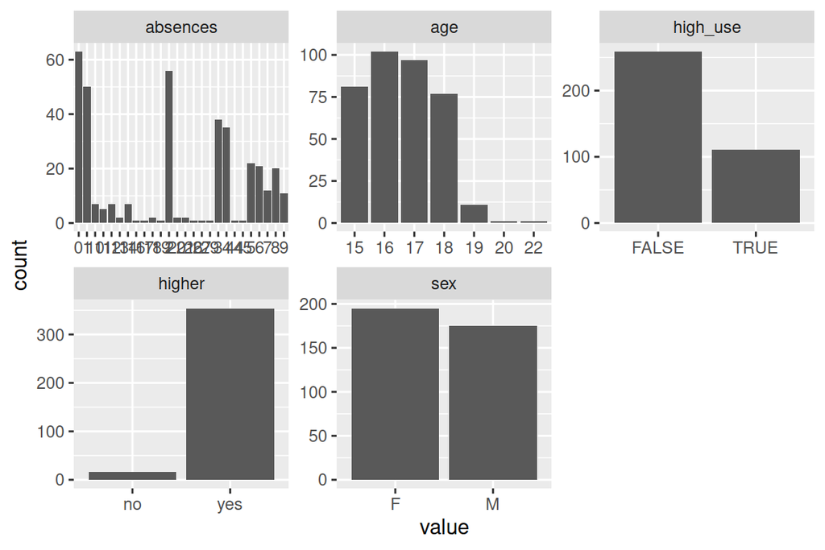

```r
gather(focals) %>% ggplot(aes(value)) + facet_wrap("key", scales = "free") + geom_bar()
```

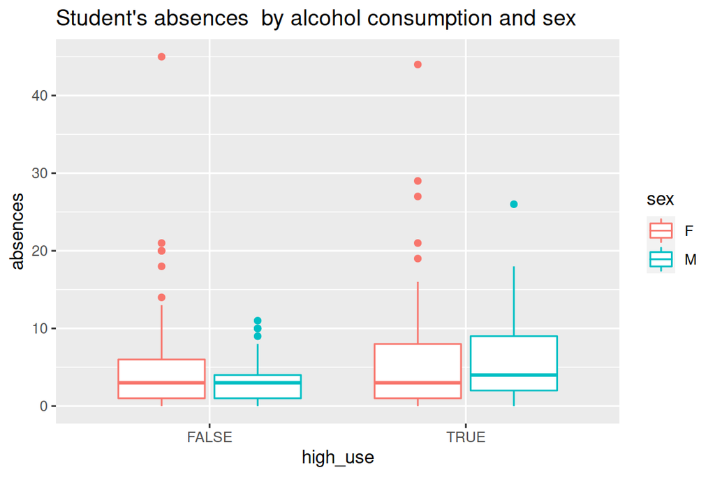

```r
g2 <- ggplot(focals, aes(x = high_use, y = absences, col = sex))
g2 + geom_boxplot() + ylab("absences") + ggtitle("Student's absences  by alcohol consumption and sex")
```

Seems like the students that have more absences quite often use more alcohol. The difference is more clear in males.

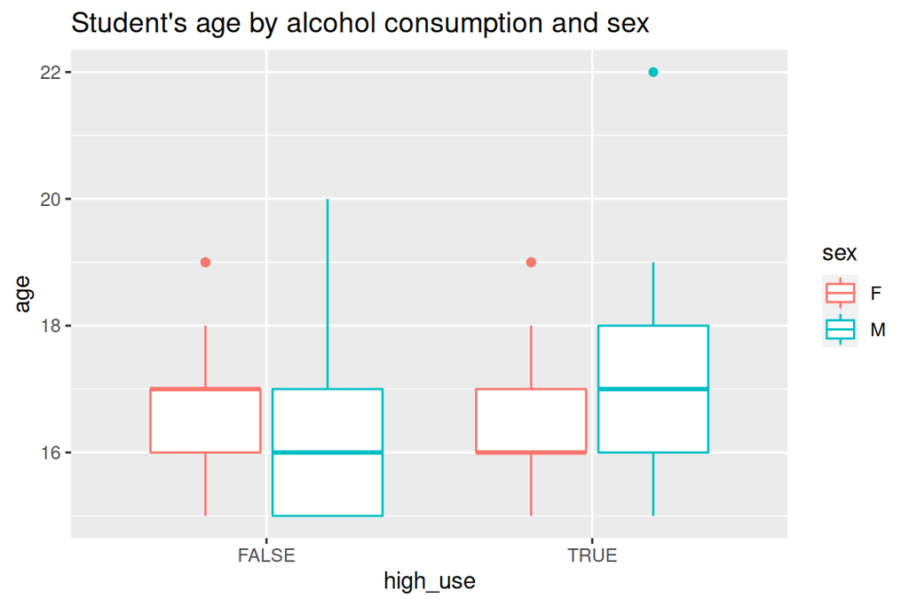

```r
g3 <- ggplot(focals, aes(x = high_use, y = age))

# define the plot as a boxplot and draw it
g3 <- g3 +  geom_boxplot() + ylab("age")

# initialize a plot of high_use and age
g3 <- ggplot(focals, aes(x = high_use, y = age, col = sex))

# define the plot as a box plot and draw it
g3 + geom_boxplot() + ylab("age") + ggtitle("Student's age by alcohol consumption and sex")
```

Older males seem to be using more alcohol than younger ones. For females there is no clear difference except in the average age, which seems to be lower in high alcohol-usage group.

```r
table(high_use = focals$high_use, sex = focals$sex)
```

```
##         sex
## high_use   F   M
##    FALSE 154 105
##    TRUE   41  70
```

```r
table(high_use = focals$high_use, sex = focals$sex, higher = focals$higher)
```

```
## , , higher = no
##
##         sex
## high_use   F   M
##    FALSE   3   4
##    TRUE    0   9
##
## , , higher = yes
##
##         sex
## high_use   F   M
##    FALSE 151 101
##    TRUE   41  61
```

Although there are less males in the data, there are still more males that use alcohol in high amounts. There are very few students that did not plan to go for higher education, thus a meaningful comparison between the differences is questionable.

## Logistic regression

Relationship between the chosen variables and the high/low alcohol consumption. The chosen variables are age, absence, sex, higher

```r
m1 <- glm(high_use ~ age + absences + sex + higher, data = studentalc, family = "binomial")
# summary of the model
summary(m1)
```

```
##
## Call:
## glm(formula = high_use ~ age + absences + sex + higher, family = "binomial",
##     data = studentalc)
##
## Deviance Residuals:
##     Min       1Q   Median       3Q      Max
## -2.5138  -0.8481  -0.6145   1.0774   2.0866
##
## Coefficients:
##             Estimate Std. Error z value Pr(>|z|)
## (Intercept) -3.43120    1.96885  -1.743   0.0814 .
## age          0.13077    0.10550   1.240   0.2151
## absences     0.09319    0.02371   3.930 8.50e-05 ***
## sexM         1.00041    0.24755   4.041 5.32e-05 ***
## higheryes   -0.58694    0.56653  -1.036   0.3002
## ---
## Signif. codes:  0 '***' 0.001 '**' 0.01 '*' 0.05 '.' 0.1 ' ' 1
##
## (Dispersion parameter for binomial family taken to be 1)
##
##     Null deviance: 452.04  on 369  degrees of freedom
## Residual deviance: 412.21  on 365  degrees of freedom
## AIC: 422.21
##
## Number of Fisher Scoring iterations: 4
```

```r
# coefficients
co <- coef(m1)
# coefficients as odds ratios
or <- coef(m1) %>% exp

# confidence intervals
ci <- confint(m1) %>% exp
# odds ratios with confidence intervals
cbind(or, ci)
```

```
##                     or        2.5 %   97.5 %
## (Intercept) 0.03234808 0.0006623013 1.521150
## age         1.13970150 0.9271314963 1.403455
## absences    1.09767298 1.0499229280 1.152322
## sexM        2.71940289 1.6836571895 4.452233
## higheryes   0.55602780 0.1784048183 1.702107
```

## Predictive power of my model

```r
# variables wit a statistical relationship with alcohol consumption
m2 <- glm(high_use ~ absences + sex, data = studentalc, family = "binomial")

# probability of high use (prediction)
probabilities <- predict(m2, type = "response")

# predicted probabilities to the original data
studentalc <- mutate(studentalc, probability = probabilities)

# prediction of high use
studentalc <- mutate(studentalc, prediction = probability > 0.5)

# how it looks like?
select(studentalc, absences, sex, high_use, probability, prediction) %>% tail(10)
```

```
##     absences sex high_use probability prediction
## 361        3   M    FALSE   0.3708919      FALSE
## 362        0   M    FALSE   0.3060791      FALSE
## 363        7   M     TRUE   0.4646683      FALSE
## 364        1   F    FALSE   0.1472516      FALSE
## 365        6   F    FALSE   0.2187809      FALSE
## 366        2   F    FALSE   0.1598138      FALSE
## 367        2   F    FALSE   0.1598138      FALSE
## 368        3   F    FALSE   0.1732299      FALSE
## 369        4   M     TRUE   0.3937240      FALSE
## 370        2   M     TRUE   0.3486225      FALSE
```

```r
# tabulate the target variable versus the predictions
table(high_use = studentalc$high_use, prediction = studentalc$prediction)
```

```
##         prediction
## high_use FALSE TRUE
##    FALSE   251    8
##    TRUE     86   25
```

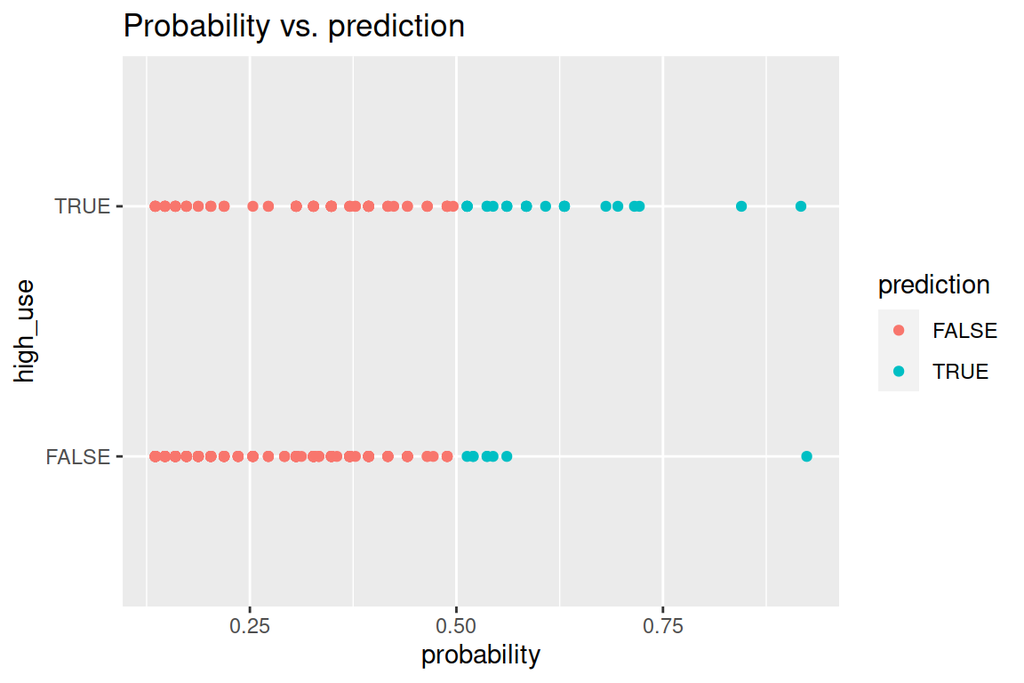

```r
# plot probability vs. prediction
g <- ggplot(studentalc, aes(x = probability, y = high_use, col = prediction))+ggtitle("Probability vs. prediction") + geom_point()
g
```

```r
# tabulate the target variable versus the predictions
table(high_use = studentalc$high_use, prediction = studentalc$prediction) %>% prop.table() %>% addmargins()
```

```
##         prediction
## high_use      FALSE       TRUE        Sum
##    FALSE 0.67837838 0.02162162 0.70000000
##    TRUE  0.23243243 0.06756757 0.30000000
##    Sum   0.91081081 0.08918919 1.00000000
```

Training error (total proportion of inaccurately classified individuals) 0.23243243 + 0.02162162 = 0.254054

## Loading the Boston data and checking the structure

```r
library(MASS)
# load the data
data("Boston")

# explore the dataset
str(Boston)
```

```
## 'data.frame':    506 obs. of  14 variables:
##  $ crim   : num  0.00632 0.02731 0.02729 0.03237 0.06905 ...
##  $ zn     : num  18 0 0 0 0 0 12.5 12.5 12.5 12.5 ...
##  $ indus  : num  2.31 7.07 7.07 2.18 2.18 2.18 7.87 7.87 7.87 7.87 ...
##  $ chas   : int  0 0 0 0 0 0 0 0 0 0 ...
##  $ nox    : num  0.538 0.469 0.469 0.458 0.458 0.458 0.524 0.524 0.524 0.524 ...
##  $ rm     : num  6.58 6.42 7.18 7 7.15 ...
##  $ age    : num  65.2 78.9 61.1 45.8 54.2 58.7 66.6 96.1 100 85.9 ...
##  $ dis    : num  4.09 4.97 4.97 6.06 6.06 ...
##  $ rad    : int  1 2 2 3 3 3 5 5 5 5 ...
##  $ tax    : num  296 242 242 222 222 222 311 311 311 311 ...
##  $ ptratio: num  15.3 17.8 17.8 18.7 18.7 18.7 15.2 15.2 15.2 15.2 ...
##  $ black  : num  397 397 393 395 397 ...
##  $ lstat  : num  4.98 9.14 4.03 2.94 5.33 ...
##  $ medv   : num  24 21.6 34.7 33.4 36.2 28.7 22.9 27.1 16.5 18.9 ...
```

```r
summary(Boston)
```

```
##       crim                zn             indus            chas
##  Min.   : 0.00632   Min.   :  0.00   Min.   : 0.46   Min.   :0.00000
##  1st Qu.: 0.08205   1st Qu.:  0.00   1st Qu.: 5.19   1st Qu.:0.00000
##  Median : 0.25651   Median :  0.00   Median : 9.69   Median :0.00000
##  Mean   : 3.61352   Mean   : 11.36   Mean   :11.14   Mean   :0.06917
##  3rd Qu.: 3.67708   3rd Qu.: 12.50   3rd Qu.:18.10   3rd Qu.:0.00000
##  Max.   :88.97620   Max.   :100.00   Max.   :27.74   Max.   :1.00000
##       nox               rm             age              dis
##  Min.   :0.3850   Min.   :3.561   Min.   :  2.90   Min.   : 1.130
##  1st Qu.:0.4490   1st Qu.:5.886   1st Qu.: 45.02   1st Qu.: 2.100
##  Median :0.5380   Median :6.208   Median : 77.50   Median : 3.207
##  Mean   :0.5547   Mean   :6.285   Mean   : 68.57   Mean   : 3.795
##  3rd Qu.:0.6240   3rd Qu.:6.623   3rd Qu.: 94.08   3rd Qu.: 5.188
##  Max.   :0.8710   Max.   :8.780   Max.   :100.00   Max.   :12.127
##       rad              tax           ptratio          black
##  Min.   : 1.000   Min.   :187.0   Min.   :12.60   Min.   :  0.32
##  1st Qu.: 4.000   1st Qu.:279.0   1st Qu.:17.40   1st Qu.:375.38
##  Median : 5.000   Median :330.0   Median :19.05   Median :391.44
##  Mean   : 9.549   Mean   :408.2   Mean   :18.46   Mean   :356.67
##  3rd Qu.:24.000   3rd Qu.:666.0   3rd Qu.:20.20   3rd Qu.:396.23
##  Max.   :24.000   Max.   :711.0   Max.   :22.00   Max.   :396.90
##      lstat            medv
##  Min.   : 1.73   Min.   : 5.00
##  1st Qu.: 6.95   1st Qu.:17.02
##  Median :11.36   Median :21.20
##  Mean   :12.65   Mean   :22.53
##  3rd Qu.:16.95   3rd Qu.:25.00
##  Max.   :37.97   Max.   :50.00
```

```r
dim(Boston)
```

```
## [1] 506  14
```

Dataset has 506 observations and 14 variables. All variables are numerical and each one describes housing values in Boston. More info on the variables can be found from [here](https://stat.ethz.ch/R-manual/R-devel/library/MASS/html/Boston.html).

## Graphical overview of the data

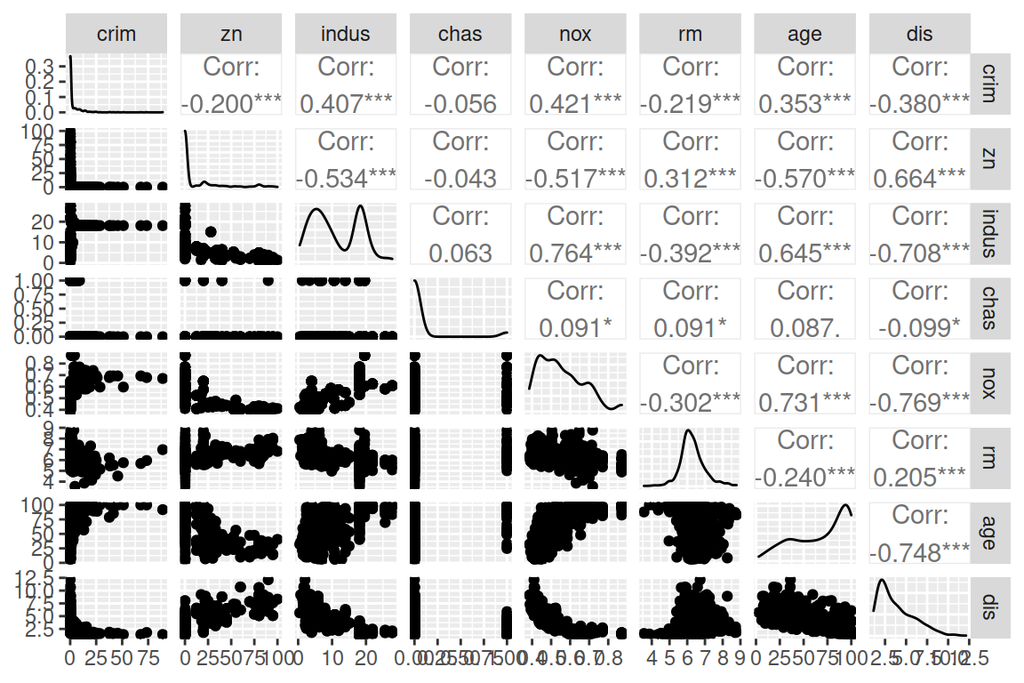

```r
# plot matrix of the variables
library(ggplot2)
library("GGally")
ggpairs(Boston[1:8])
```

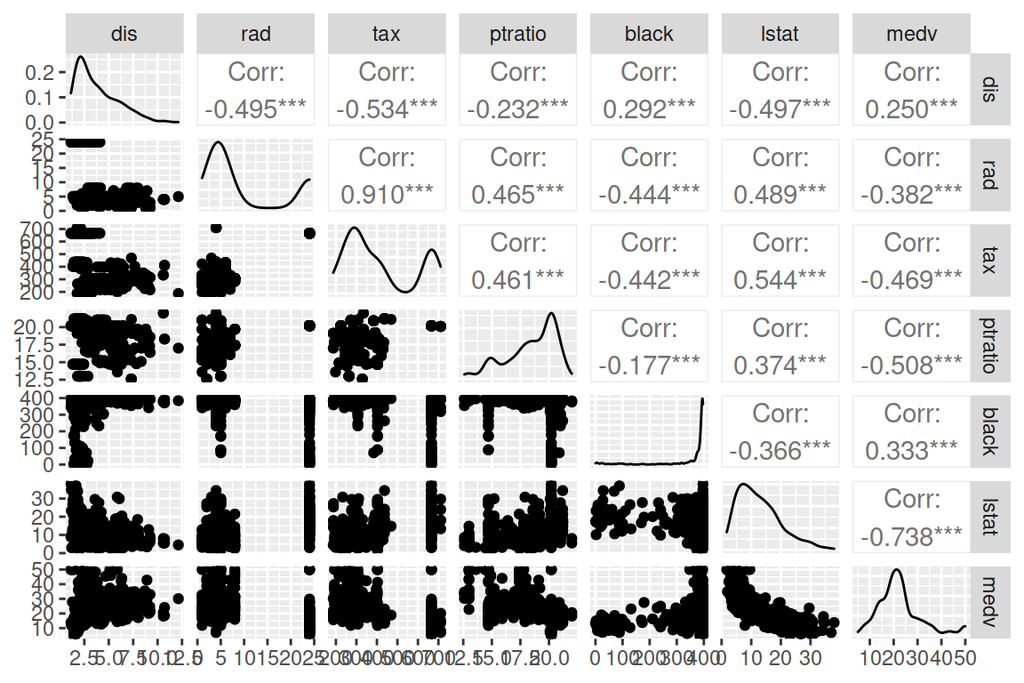

```r
ggpairs(Boston[8:14])
```

There are plenty of variables in the data that correlate significantly as can be seen from the Pearson correlation coefficients that are displayed on the right hand side of the plot. Next, I will use a correlation matrix to get a better view and to be able to distinguish the variables that stand up from the data.

```r
cor_matrix <- cor(Boston)
cor_matrix <- round(cor_matrix, digits = 2)
# rounded correlation matrix
cor_matrix
```

```
##          crim    zn indus  chas   nox    rm   age   dis   rad   tax ptratio
## crim     1.00 -0.20  0.41 -0.06  0.42 -0.22  0.35 -0.38  0.63  0.58    0.29
## zn      -0.20  1.00 -0.53 -0.04 -0.52  0.31 -0.57  0.66 -0.31 -0.31   -0.39
## indus    0.41 -0.53  1.00  0.06  0.76 -0.39  0.64 -0.71  0.60  0.72    0.38
## chas    -0.06 -0.04  0.06  1.00  0.09  0.09  0.09 -0.10 -0.01 -0.04   -0.12
## nox      0.42 -0.52  0.76  0.09  1.00 -0.30  0.73 -0.77  0.61  0.67    0.19
## rm      -0.22  0.31 -0.39  0.09 -0.30  1.00 -0.24  0.21 -0.21 -0.29   -0.36
## age      0.35 -0.57  0.64  0.09  0.73 -0.24  1.00 -0.75  0.46  0.51    0.26
## dis     -0.38  0.66 -0.71 -0.10 -0.77  0.21 -0.75  1.00 -0.49 -0.53   -0.23
## rad      0.63 -0.31  0.60 -0.01  0.61 -0.21  0.46 -0.49  1.00  0.91    0.46
## tax      0.58 -0.31  0.72 -0.04  0.67 -0.29  0.51 -0.53  0.91  1.00    0.46
## ptratio  0.29 -0.39  0.38 -0.12  0.19 -0.36  0.26 -0.23  0.46  0.46    1.00
## black   -0.39  0.18 -0.36  0.05 -0.38  0.13 -0.27  0.29 -0.44 -0.44   -0.18
## lstat    0.46 -0.41  0.60 -0.05  0.59 -0.61  0.60 -0.50  0.49  0.54    0.37
## medv    -0.39  0.36 -0.48  0.18 -0.43  0.70 -0.38  0.25 -0.38 -0.47   -0.51
##         black lstat  medv
## crim    -0.39  0.46 -0.39
## zn       0.18 -0.41  0.36
## indus   -0.36  0.60 -0.48
## chas     0.05 -0.05  0.18
## nox     -0.38  0.59 -0.43
## rm       0.13 -0.61  0.70
## age     -0.27  0.60 -0.38
## dis      0.29 -0.50  0.25
## rad     -0.44  0.49 -0.38
## tax     -0.44  0.54 -0.47
## ptratio -0.18  0.37 -0.51
## black    1.00 -0.37  0.33
## lstat   -0.37  1.00 -0.74
## medv     0.33 -0.74  1.00
```

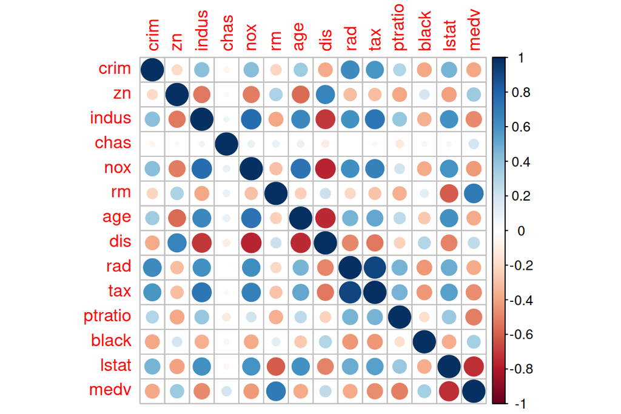

```r
# visualize the correlation matrix
library(corrplot)
corrplot(cor_matrix, method="circle")
```

Correlation plot of the variables in the Boston data

Tax (full value property tax-rate per 10 000 dollars) and rad (index of accessibility to radial highways) 0.910 ***.

Lstat (lower status of the populaitons) and medv (median value of owner occupied houses in 1000$s) -0.738***

Indus (proportion of non retail business acres per town) and dis (weighed mean of distances to five boston employment centers) -0.708***.

## Standardize the dataset and print out summaries of the scaled data

Scaling means that the column means are first subtracted from the columns and then divided by the standard deviation. Scaling will shift the mean to 0 as we can see here.

```r
boston_scaled <- scale(Boston)
summary(boston_scaled)
```

```
##       crim                 zn               indus              chas
##  Min.   :-0.419367   Min.   :-0.48724   Min.   :-1.5563   Min.   :-0.2723
##  1st Qu.:-0.410563   1st Qu.:-0.48724   1st Qu.:-0.8668   1st Qu.:-0.2723
##  Median :-0.390280   Median :-0.48724   Median :-0.2109   Median :-0.2723
##  Mean   : 0.000000   Mean   : 0.00000   Mean   : 0.0000   Mean   : 0.0000
##  3rd Qu.: 0.007389   3rd Qu.: 0.04872   3rd Qu.: 1.0150   3rd Qu.:-0.2723
##  Max.   : 9.924110   Max.   : 3.80047   Max.   : 2.4202   Max.   : 3.6648
##       nox                rm               age               dis
##  Min.   :-1.4644   Min.   :-3.8764   Min.   :-2.3331   Min.   :-1.2658
##  1st Qu.:-0.9121   1st Qu.:-0.5681   1st Qu.:-0.8366   1st Qu.:-0.8049
##  Median :-0.1441   Median :-0.1084   Median : 0.3171   Median :-0.2790
##  Mean   : 0.0000   Mean   : 0.0000   Mean   : 0.0000   Mean   : 0.0000
##  3rd Qu.: 0.5981   3rd Qu.: 0.4823   3rd Qu.: 0.9059   3rd Qu.: 0.6617
##  Max.   : 2.7296   Max.   : 3.5515   Max.   : 1.1164   Max.   : 3.9566
##       rad               tax             ptratio            black
##  Min.   :-0.9819   Min.   :-1.3127   Min.   :-2.7047   Min.   :-3.9033
##  1st Qu.:-0.6373   1st Qu.:-0.7668   1st Qu.:-0.4876   1st Qu.: 0.2049
##  Median :-0.5225   Median :-0.4642   Median : 0.2746   Median : 0.3808
##  Mean   : 0.0000   Mean   : 0.0000   Mean   : 0.0000   Mean   : 0.0000
##  3rd Qu.: 1.6596   3rd Qu.: 1.5294   3rd Qu.: 0.8058   3rd Qu.: 0.4332
##  Max.   : 1.6596   Max.   : 1.7964   Max.   : 1.6372   Max.   : 0.4406
##      lstat              medv
##  Min.   :-1.5296   Min.   :-1.9063
##  1st Qu.:-0.7986   1st Qu.:-0.5989
##  Median :-0.1811   Median :-0.1449
##  Mean   : 0.0000   Mean   : 0.0000
##  3rd Qu.: 0.6024   3rd Qu.: 0.2683
##  Max.   : 3.5453   Max.   : 2.9865
```

```r
summary(Boston)
```

```
##       crim                zn             indus            chas
##  Min.   : 0.00632   Min.   :  0.00   Min.   : 0.46   Min.   :0.00000
##  1st Qu.: 0.08205   1st Qu.:  0.00   1st Qu.: 5.19   1st Qu.:0.00000
##  Median : 0.25651   Median :  0.00   Median : 9.69   Median :0.00000
##  Mean   : 3.61352   Mean   : 11.36   Mean   :11.14   Mean   :0.06917
##  3rd Qu.: 3.67708   3rd Qu.: 12.50   3rd Qu.:18.10   3rd Qu.:0.00000
##  Max.   :88.97620   Max.   :100.00   Max.   :27.74   Max.   :1.00000
##       nox               rm             age              dis
##  Min.   :0.3850   Min.   :3.561   Min.   :  2.90   Min.   : 1.130
##  1st Qu.:0.4490   1st Qu.:5.886   1st Qu.: 45.02   1st Qu.: 2.100
##  Median :0.5380   Median :6.208   Median : 77.50   Median : 3.207
##  Mean   :0.5547   Mean   :6.285   Mean   : 68.57   Mean   : 3.795
##  3rd Qu.:0.6240   3rd Qu.:6.623   3rd Qu.: 94.08   3rd Qu.: 5.188
##  Max.   :0.8710   Max.   :8.780   Max.   :100.00   Max.   :12.127
##       rad              tax           ptratio          black
##  Min.   : 1.000   Min.   :187.0   Min.   :12.60   Min.   :  0.32
##  1st Qu.: 4.000   1st Qu.:279.0   1st Qu.:17.40   1st Qu.:375.38
##  Median : 5.000   Median :330.0   Median :19.05   Median :391.44
##  Mean   : 9.549   Mean   :408.2   Mean   :18.46   Mean   :356.67
##  3rd Qu.:24.000   3rd Qu.:666.0   3rd Qu.:20.20   3rd Qu.:396.23
##  Max.   :24.000   Max.   :711.0   Max.   :22.00   Max.   :396.90
##      lstat            medv
##  Min.   : 1.73   Min.   : 5.00
##  1st Qu.: 6.95   1st Qu.:17.02
##  Median :11.36   Median :21.20
##  Mean   :12.65   Mean   :22.53
##  3rd Qu.:16.95   3rd Qu.:25.00
##  Max.   :37.97   Max.   :50.00
```

```r
# change into a data frame for future use
class(boston_scaled)
```

```
## [1] "matrix" "array"
```

```r
boston_scaled <- as.data.frame(boston_scaled)
```

## Turn crime rate into categorical variable, use quantiles as the break points and replace the old crime rate variable with the new one

```r
summary(boston_scaled$crim)
```

```
##      Min.   1st Qu.    Median      Mean   3rd Qu.      Max.
## -0.419367 -0.410563 -0.390280  0.000000  0.007389  9.924110
```

```r
# creating a quantile vector
bins <- quantile(boston_scaled$crim)
bins
```

```
##           0%          25%          50%          75%         100%
## -0.419366929 -0.410563278 -0.390280295  0.007389247  9.924109610
```

```r
# next a categorical variable
labelsadd <- c("low", "med_low", "med_high", "high")
crime <- cut(boston_scaled$crim, breaks = bins, include.lowest = TRUE, labels = labelsadd)
# how does it look like?
table(crime)
```

```
## crime
##      low  med_low med_high     high
##      127      126      126      127
```

```r
# Replacing the old crim with the new catergorical crim
boston_scaled <- dplyr::select(boston_scaled, -crim)
boston_scaled <- data.frame(boston_scaled, crime)
```

## Divide the dataset into train and test sets (80% to the train set)

```r
# number of rows
nrow(boston_scaled)
```

```
## [1] 506
```

```r
n <- 506

# randomly select 80% of the rows
ind <- sample(n,  size = n * 0.8)

# create the train set
train <- boston_scaled[ind,]

# and the test set
test <- boston_scaled[-ind,]

# correct classes from the test data
correct_classes <- test$crime

# remove the crime variable from test data
test <- dplyr::select(test, -crime)
```

## Fit the linear discriminant analysis on the train set using the categorical crime rate as the target and all other variables as predictors and draw the LDA plot

```r
library(MASS)

# linear discriminant analysis
lda.fit <- lda(crime ~., data = train)
lda.fit
```

```
## Call:
## lda(crime ~ ., data = train)
##
## Prior probabilities of groups:
##       low   med_low  med_high      high
## 0.2475248 0.2376238 0.2524752 0.2623762
##
## Group means:
##                  zn      indus        chas        nox          rm        age
## low       0.9911635 -0.8943678 -0.07547406 -0.8613916  0.43606339 -0.8983632
## med_low  -0.1100554 -0.2275313  0.01475116 -0.5399665 -0.12262044 -0.3586182
## med_high -0.3846714  0.2112573  0.19085920  0.3378397  0.09991066  0.4156683
## high     -0.4872402  1.0149946 -0.04947434  0.9919637 -0.40154783  0.8049055
##                 dis        rad        tax     ptratio      black        lstat
## low       0.8474544 -0.6936060 -0.7373874 -0.49864238  0.3739112 -0.765595316
## med_low   0.3453007 -0.5619629 -0.4705175 -0.05452035  0.3405612 -0.121311433
## med_high -0.3692451 -0.4143934 -0.3029640 -0.23577293  0.1285953 -0.006401051
## high     -0.8556927  1.6596029  1.5294129  0.80577843 -0.8537304  0.869427446
##                 medv
## low       0.51561814
## med_low   0.02542761
## med_high  0.16752263
## high     -0.66640898
##
## Coefficients of linear discriminants:
##                 LD1          LD2         LD3
## zn       0.15030261  0.804135122 -0.92574384
## indus    0.01465196 -0.273769020  0.35900915
## chas    -0.07569180 -0.049963463  0.08857759
## nox      0.15454128 -0.685608311 -1.30997366
## rm      -0.08932688 -0.065989019 -0.13911926
## age      0.33423068 -0.324614420 -0.23100847
## dis     -0.17824509 -0.388231852  0.35735807
## rad      3.49123456  0.929355997 -0.08581676
## tax     -0.01326619 -0.121790525  0.61806460
## ptratio  0.12967349  0.072050627 -0.20321037
## black   -0.16320848 -0.008832519  0.13013379
## lstat    0.19462552 -0.274429784  0.45239508
## medv     0.15905113 -0.399940244 -0.05729722
##
## Proportion of trace:
##    LD1    LD2    LD3
## 0.9575 0.0321 0.0103
```

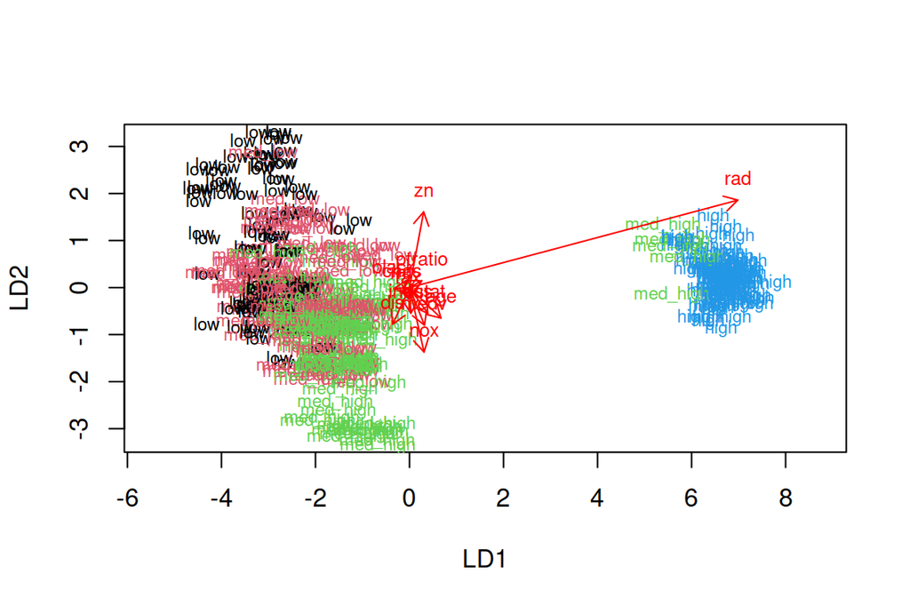

```r
# biplot arrows
lda.arrows <- function(x, myscale = 1, arrow_heads = 0.1, color = "red", tex = 0.75, choices = c(1,2)){
  heads <- coef(x)
  arrows(x0 = 0, y0 = 0,
         x1 = myscale * heads[,choices[1]],
         y1 = myscale * heads[,choices[2]], col=color, length = arrow_heads)
  text(myscale * heads[,choices], labels = row.names(heads),
       cex = tex, col=color, pos=3)
}

# target classes as numeric
classes <- as.numeric(train$crime)

# LDA plot
plot(lda.fit, dimen = 2, col = classes, pch = classes)
lda.arrows(lda.fit, myscale = 2)
```

## Predict the classes with the LDA model on the test data and cross tabulate the results with crime categories from the test set

Crime categories have already been saved from the test set and categorical crime variable has been removed from the test dataset.

```r
# predict classes with test data
lda.pred <- predict(lda.fit, newdata = test)

# cross tabulate the results
table(correct = correct_classes, predicted = lda.pred$class)
```

```
##           predicted
## correct    low med_low med_high high
##   low       16      10        1    0
##   med_low    5      19        6    0
##   med_high   0       4       19    1
##   high       0       0        1   20
```

## Reload and standardize the Boston dataset

```r
data("Boston")
dim(Boston)
```

```
## [1] 506  14
```

```r
boston_scaled <- scale(Boston)
summary(boston_scaled)
```

```
##       crim                 zn               indus              chas
##  Min.   :-0.419367   Min.   :-0.48724   Min.   :-1.5563   Min.   :-0.2723
##  1st Qu.:-0.410563   1st Qu.:-0.48724   1st Qu.:-0.8668   1st Qu.:-0.2723
##  Median :-0.390280   Median :-0.48724   Median :-0.2109   Median :-0.2723
##  Mean   : 0.000000   Mean   : 0.00000   Mean   : 0.0000   Mean   : 0.0000
##  3rd Qu.: 0.007389   3rd Qu.: 0.04872   3rd Qu.: 1.0150   3rd Qu.:-0.2723
##  Max.   : 9.924110   Max.   : 3.80047   Max.   : 2.4202   Max.   : 3.6648
##       nox                rm               age               dis
##  Min.   :-1.4644   Min.   :-3.8764   Min.   :-2.3331   Min.   :-1.2658
##  1st Qu.:-0.9121   1st Qu.:-0.5681   1st Qu.:-0.8366   1st Qu.:-0.8049
##  Median :-0.1441   Median :-0.1084   Median : 0.3171   Median :-0.2790
##  Mean   : 0.0000   Mean   : 0.0000   Mean   : 0.0000   Mean   : 0.0000
##  3rd Qu.: 0.5981   3rd Qu.: 0.4823   3rd Qu.: 0.9059   3rd Qu.: 0.6617
##  Max.   : 2.7296   Max.   : 3.5515   Max.   : 1.1164   Max.   : 3.9566
##       rad               tax             ptratio            black
##  Min.   :-0.9819   Min.   :-1.3127   Min.   :-2.7047   Min.   :-3.9033
##  1st Qu.:-0.6373   1st Qu.:-0.7668   1st Qu.:-0.4876   1st Qu.: 0.2049
##  Median :-0.5225   Median :-0.4642   Median : 0.2746   Median : 0.3808
##  Mean   : 0.0000   Mean   : 0.0000   Mean   : 0.0000   Mean   : 0.0000
##  3rd Qu.: 1.6596   3rd Qu.: 1.5294   3rd Qu.: 0.8058   3rd Qu.: 0.4332
##  Max.   : 1.6596   Max.   : 1.7964   Max.   : 1.6372   Max.   : 0.4406
##      lstat              medv
##  Min.   :-1.5296   Min.   :-1.9063
##  1st Qu.:-0.7986   1st Qu.:-0.5989
##  Median :-0.1811   Median :-0.1449
##  Mean   : 0.0000   Mean   : 0.0000
##  3rd Qu.: 0.6024   3rd Qu.: 0.2683
##  Max.   : 3.5453   Max.   : 2.9865
```

```r
class(boston_scaled)
```

```
## [1] "matrix" "array"
```

```r
boston_scaled <- as.data.frame(boston_scaled)
```

## Calculate the distances between the observations

```r
# euclidean distance matrix
dist_eu <- dist(boston_scaled)

# look at the summary of the distances
summary(dist_eu)
```

```
##    Min. 1st Qu.  Median    Mean 3rd Qu.    Max.
##  0.1343  3.4625  4.8241  4.9111  6.1863 14.3970
```

## Run k-means algorithm on the dataset

```r
library(tidyverse)
# k-means
km <- kmeans(Boston, centers = 4)
```

This is where I ran into an issue. I can’t make the exercise to work. If I try to run the code to calculate the total within sum of squares, the function twcss <- sapply(1:k_max, function(k){kmeans(Boston, k)$tot.withinss}) produces following error: “Warning: numerical expression has 9 elements: only the first usedError in 1:k_max : NA/NaN argument.”